# FE8828 Assignment for Exploratory Data Analysis

Liu Nuozhou <sub><Email:liun0008@e.ntu.edu.sg></sub>

Oct 2019

# Finding #1

```r
# Find the big balance group
bank %>%   group_by(balance_decile = ntile(balance,10)) %>%
  summarise(average_balance=mean(balance)) %>%
  arrange(balance_decile) -> decile_balancemean
# Average balance of 10 groups
decile_balancemean
```

```
## # A tibble: 10 x 2
##    balance_decile average_balance
##             <int>           <dbl>
##  1              1         -266.
##  2              2            3.73
##  3              3           71.8
##  4              4          194.
##  5              5          353.
##  6              6          573.
##  7              7          912.
##  8              8         1500.
##  9              9         2813.
## 10             10         8076.
```

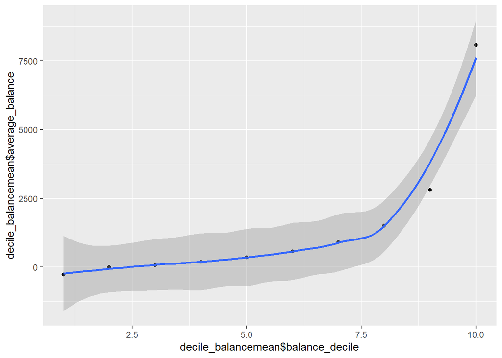

```r
ggplot(decile_balancemean,aes(x=decile_balancemean$balance_decile,y = decile_balancemean$average_balance))+
  geom_point()+
  geom_smooth()
## `geom_smooth()` using method = 'loess' and formula 'y ~ x'
```

The table and graph demonstrate serious uneven distribution of balance. The total balance of the top decile group is even larger than the sum of other 9 groups’ balances.

# Findings about term-deposits

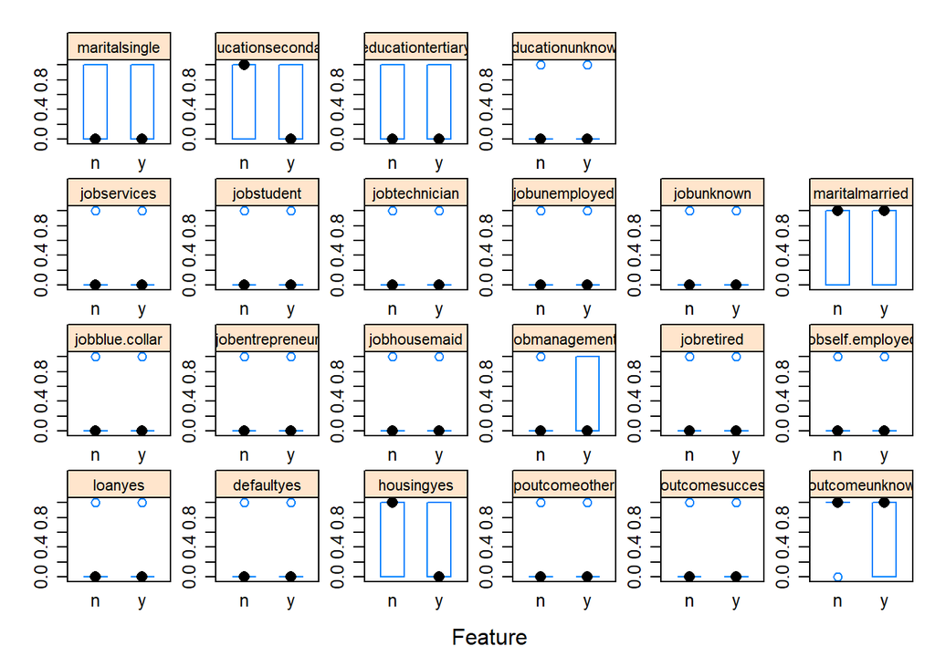

```r
#Think about possible relations between deposits and other features
bank_fit <- bank %>% select(y, loan, default, housing, poutcome, job, marital,education) %>% mutate_if(is.factor, as.character) %>% mutate(y = ifelse(y == "yes", "y", "n"))
dummies <- dummyVars("y ~ loan + default + housing + poutcome + job + marital + education", data = bank_fit, fullRank = TRUE)
bank_new <- data.frame(predict(dummies, newdata = bank_fit))
bank_new <- bind_cols(bank_fit["y"], bank_new) %>% mutate(y = factor(y))
featurePlot(x = bank_new[-1], y = bank_new$y, plot = "box", strip=strip.custom(par.strip.text=list(cex=.7)), scales = list(x = list(relation="free"), y = list(relation="free")))
```

# Finding #2

From box plots above, we find that: (1)Customers with secondary education are more likely to have no term deposits than others. (2)Customers with housing loans are less likely to possess term deposits, which is quite intuitive.

# Findings about default

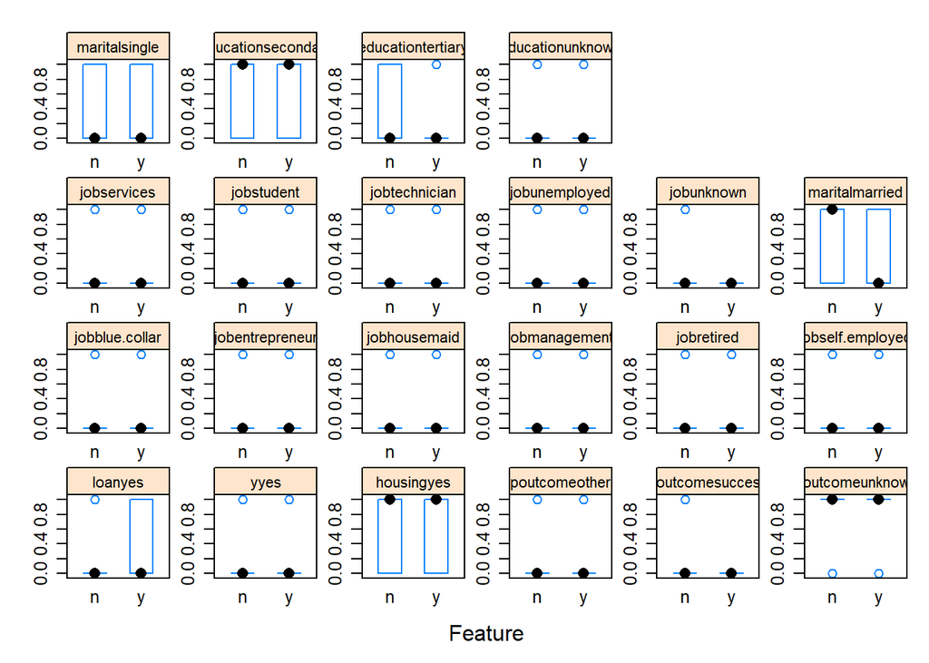

```r
#Think about possible relations between default and other features
bank_fit <- bank %>% select(default, loan, y, housing, poutcome, job, marital,education) %>% mutate_if(is.factor, as.character) %>% mutate(default = ifelse(default == "yes", "y", "n"))
dummies <- dummyVars("default ~ loan + y + housing + poutcome + job + marital + education", data = bank_fit, fullRank = TRUE)
bank_new <- data.frame(predict(dummies, newdata = bank_fit))
bank_new <- bind_cols(bank_fit["default"], bank_new) %>% mutate(default = factor(default))
featurePlot(x = bank_new[-1], y = bank_new$default, plot = "box", strip=strip.custom(par.strip.text=list(cex=.7)), scales = list(x = list(relation="free"), y = list(relation="free")))
```

# Finding #3

It seems that married customers are less likely to default compared with others. Interesting but reasonable.

# Findings regarding housing loans

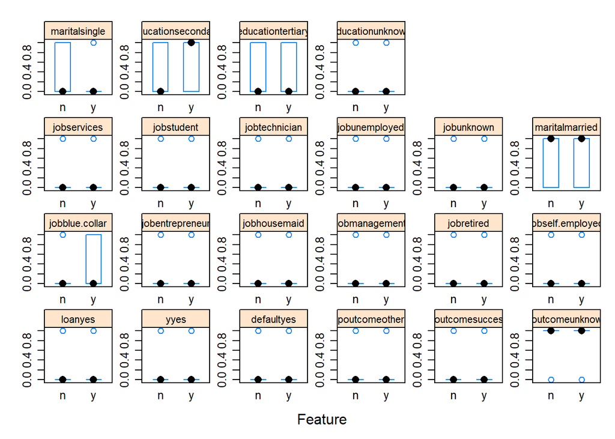

```r
#Think about possible relations between housing loan and other features
bank_fit <- bank %>% select(housing, default, loan, y, poutcome, job, marital,education) %>% mutate_if(is.factor, as.character) %>% mutate(housing = ifelse(housing == "yes", "y", "n"))
dummies <- dummyVars("housing ~ loan + y + default + poutcome + job + marital + education", data = bank_fit, fullRank = TRUE)
bank_new <- data.frame(predict(dummies, newdata = bank_fit))
bank_new <- bind_cols(bank_fit["housing"], bank_new) %>% mutate(housing = factor(housing))
featurePlot(x = bank_new[-1], y = bank_new$housing, plot = "box", strip=strip.custom(par.strip.text=list(cex=.7)), scales = list(x = list(relation="free"), y = list(relation="free")))
```

# Finding #4 Customers with secondary education are more likely to have housing loans than others.

# Findings regarding personal loans

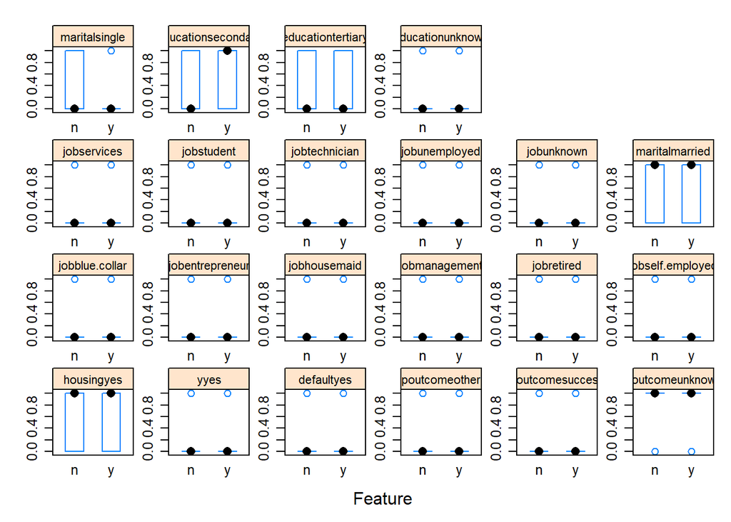

```r
#Think about possible relations between personal loan and other features
bank_fit <- bank %>% select(loan, housing, default, y, poutcome, job, marital,education) %>% mutate_if(is.factor, as.character) %>% mutate(loan = ifelse(loan == "yes", "y", "n"))
dummies <- dummyVars("loan ~ housing + y + default + poutcome + job + marital + education", data = bank_fit, fullRank = TRUE)
bank_new <- data.frame(predict(dummies, newdata = bank_fit))
bank_new <- bind_cols(bank_fit["loan"], bank_new) %>% mutate(loan = factor(loan))
featurePlot(x = bank_new[-1], y = bank_new$loan, plot = "box", strip=strip.custom(par.strip.text=list(cex=.7)), scales = list(x = list(relation="free"), y = list(relation="free")))
```

# Finding #5

Again, customers with secondary education are more inclined to possess personal loans than those in other education backgrouds.

# Findings regarding education level

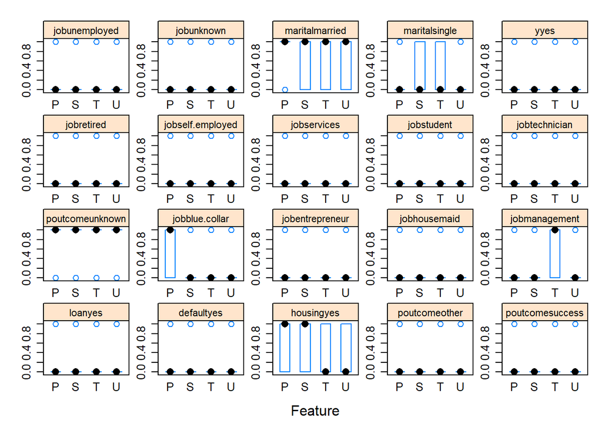

```r
#Try to find out relations among education level and other features
bank_fit <- bank %>% select(education, loan, default, housing, poutcome, job, marital,y) %>% mutate_if(is.factor, as.character) %>% mutate(education=case_when(
   education=="primary" ~ "P",
   education=="secondary" ~ "S",
   education=="tertiary" ~ "T",
   education=="unknown" ~ "U"
   )
 )
dummies <- dummyVars("education ~ loan + default + housing + poutcome + job + marital + y", data = bank_fit, fullRank = TRUE)
bank_new <- data.frame(predict(dummies, newdata = bank_fit))
bank_new <- bind_cols(bank_fit["education"], bank_new) %>% mutate(education = factor(education))
featurePlot(x = bank_new[-1], y = bank_new$education, plot = "box", strip=strip.custom(par.strip.text=list(cex=.7)), scales = list(x = list(relation="free"), y = list(relation="free")))
```

There are in total 187 customers whose education levels are unknown, which is quite a small part and hence we can just ignore it. From those graphs, we can see some interesting phenomenons.

# Finding #6

1. Customers with primary education are more likely to do blue collar jobs.
2. Customers with tertiary education are more likely to be managements.
3. Meanwhile, those with tertiary education are also less likely to have housing loans, maybe most of them are able to buy their houses with their earnings. All those phenomenons are intuitive and illuminating: education counts a lot.

# Finding #7

```r
bank %>% group_by(education) %>%
   summarise(average_balance=mean(balance)) -> ed_ba
ed_ba
```

```
## # A tibble: 4 x 2
##   education average_balance
##   <fct>               <dbl>
## 1 primary             1412.
## 2 secondary           1197.
## 3 tertiary            1775.
## 4 unknown             1701.
```

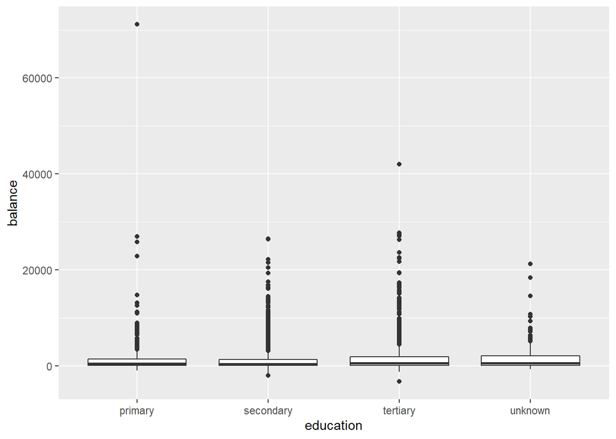

```r
ggplot(bank,aes(x=education,y=balance)) +
  geom_boxplot()
```

Customers with tertiary education have the highest average balance, but customers with only primary education have higher average balance than those with secondary education, which is pretty counterintuitive. From the boxplot, I reckon that maybe some outliers in the primary group significantly affect the group average.

# Finding #8

```r
#fathom out relation between job and balance
bank %>% group_by(job) %>%
  summarise(average_balance=mean(balance)) -> job_ba
arrange(job_ba,average_balance)
```

```
## # A tibble: 12 x 2
##    job           average_balance
##    <fct>                   <dbl>
##  1 blue-collar             1085.
##  2 unemployed              1089.
##  3 services                1104.
##  4 admin.                  1227.
##  5 technician              1331.
##  6 self-employed           1392.
##  7 unknown                 1502.
##  8 student                 1544.
##  9 entrepreneur            1645.
## 10 management              1767.
## 11 housemaid               2084.
## 12 retired                 2319.
```

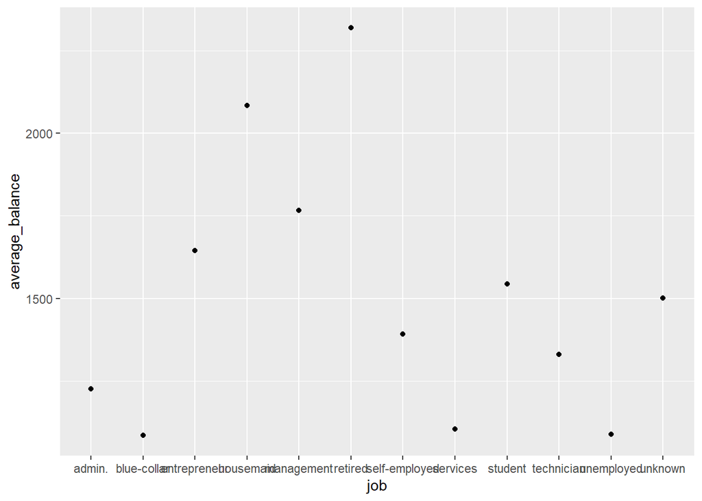

```r
ggplot(job_ba,aes(x=job,y=average_balance))+
  geom_point()
```

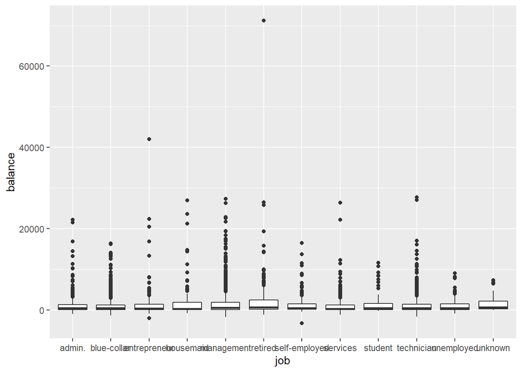

```r
ggplot(bank,aes(x=job,y=balance)) +
  geom_boxplot()
```

Customers who are retired have the highest average balance, but the second highest group is housemaid, even higher than management and entrepreneur, which is a bit surprising. Another interesting fact is that the unemployed seem to have higher balance than blue-collar workers. Maybe unemployment benefits are quite high in this country.

# Finding #9

Further fathom out how come housemaids have so much bank balances. There are in total 112 housemaid customers.

```r
housemaids<-filter(bank,job=="housemaid")
bank_summary <- function(df) {
  df %>%
    group_by(education, marital) %>%
    summarise(age_mean = mean(age), balance_mean = mean(balance)) %>%
    ungroup() %>% # after ungroup, job and education are "unlocked" to be converted to character
    mutate_if(is.factor, as.character)
}
df_1 <- housemaids %>%
  bank_summary()
df_2 <- housemaids %>%
  mutate(marital = "+") %>%
  bank_summary()
df_3 <- housemaids %>%
  mutate(education = "+") %>%
  bank_summary()
bind_rows(df_1, df_2, df_3)
```

```
## # A tibble: 18 x 4
##    education marital  age_mean balance_mean
##    <chr>     <chr>       <dbl>        <dbl>
##  1 primary   divorced     51.7         454.
##  2 primary   married      49.8        1405.
##  3 primary   single       37.3       10949.
##  4 secondary divorced     43          2341.
##  5 secondary married      48.8        2111
##  6 secondary single       42.7         803
##  7 tertiary  divorced     46.5         367
##  8 tertiary  married      43.3        1394.
##  9 tertiary  single       40.1        4397.
## 10 unknown   married      46.8        5353
## 11 unknown   single       50             0
## 12 primary   +            49.3        1807.
## 13 secondary +            47.1        2012.
## 14 tertiary  +            42.5        2393.
## 15 unknown   +            47.4        4282.
## 16 +         divorced     47.5        1166.
## 17 +         married      48.5        1759.
## 18 +         single       40.7        4695.
```

# Finding #10

At last, let’s figure out which features have significant impacts on balance. Here, to take into account balance and age, balances and ages are equally divided into 5 groups from low to high and marked with “1-5” as per their values. The higher the value, the larger the number.

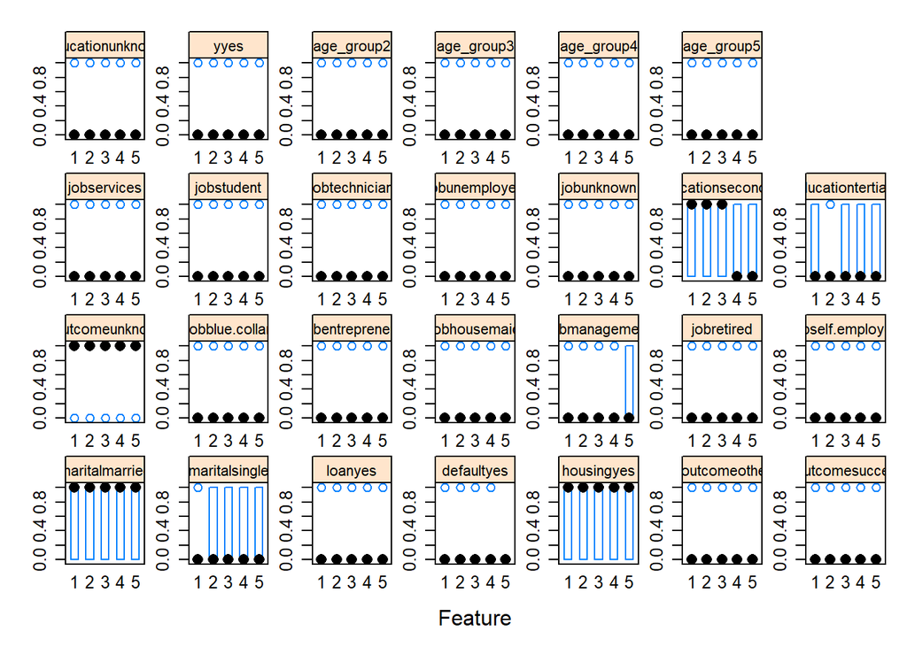

```r
bank1<-mutate(bank,balance_group=as.character(ntile(balance,5)),age_group=as.character(ntile(age,5)))
bank_fit <- bank1 %>% select(balance_group, marital, education, loan, default, housing, poutcome, job, y, age_group) %>% mutate_if(is.factor, as.character)
dummies <- dummyVars("balance_group ~ marital + loan + default + housing + poutcome + job + education + y + age_group", data = bank_fit, fullRank = TRUE)
bank_new <- data.frame(predict(dummies, newdata = bank_fit))
bank_new <- bind_cols(bank_fit["balance_group"], bank_new)%>% mutate(balance_group = factor(balance_group))
featurePlot(x = bank_new[-1], y = bank_new$balance_group, plot = "box", strip=strip.custom(par.strip.text=list(cex=.7)), scales = list(x = list(relation="free"), y = list(relation="free")))
```